# Prosper Loan Data Analysis

## by Mohammed Barakah

This dataset originates from Prosper, the pioneering peer-to-peer lending platform in the United States, known for facilitating over $7 billion in funded loans. It comprises 113,937 individual loans, each associated with 81 distinct variables.

## Preliminary Wrangling

```python
# import all packages and set plots to be embedded inline
import numpy as np
import pandas as pd
import matplotlib.pyplot as plt
import seaborn as sb

%matplotlib inline
```

```python
df = pd.read_csv('prosperLoanData.csv')
```

```python
df.head()
```

|  | ListingKey | ListingNumber | ListingCreationDate | CreditGrade | Term | LoanStatus | ClosedDate | BorrowerAPR | BorrowerRate | LenderYield | ... | LP_ServiceFees | LP_CollectionFees | LP_GrossPrincipalLoss | LP_NetPrincipalLoss | LP_NonPrincipalRecoverypayments | PercentFunded | Recommendations | InvestmentFromFriendsCount | InvestmentFromFriendsAmount | Investors |
| --- | --- | --- | --- | --- | --- | --- | --- | --- | --- | --- | --- | --- | --- | --- | --- | --- | --- | --- | --- | --- | --- |
| 0 | 1021339766868145413AB3B | 193129 | 2007-08-26 19:09:29.263000000 | C | 36 | Completed | 2009-08-14 00:00:00 | 0.16516 | 0.1580 | 0.1380 | ... | -133.18 | 0.0 | 0.0 | 0.0 | 0.0 | 1.0 | 0 | 0 | 0.0 | 258 |
| 1 | 10273602499503308B223C1 | 1209647 | 2014-02-27 08:28:07.900000000 | NaN | 36 | Current | NaN | 0.12016 | 0.0920 | 0.0820 | ... | 0.00 | 0.0 | 0.0 | 0.0 | 0.0 | 1.0 | 0 | 0 | 0.0 | 1 |
| 2 | 0EE9337825851032864889A | 81716 | 2007-01-05 15:00:47.090000000 | HR | 36 | Completed | 2009-12-17 00:00:00 | 0.28269 | 0.2750 | 0.2400 | ... | -24.20 | 0.0 | 0.0 | 0.0 | 0.0 | 1.0 | 0 | 0 | 0.0 | 41 |
| 3 | 0EF5356002482715299901A | 658116 | 2012-10-22 11:02:35.010000000 | NaN | 36 | Current | NaN | 0.12528 | 0.0974 | 0.0874 | ... | -108.01 | 0.0 | 0.0 | 0.0 | 0.0 | 1.0 | 0 | 0 | 0.0 | 158 |
| 4 | 0F023589499656230C5E3E2 | 909464 | 2013-09-14 18:38:39.097000000 | NaN | 36 | Current | NaN | 0.24614 | 0.2085 | 0.1985 | ... | -60.27 | 0.0 | 0.0 | 0.0 | 0.0 | 1.0 | 0 | 0 | 0.0 | 20 |

5 rows × 81 columns

```python
df.describe()
```

|  | ListingNumber | Term | BorrowerAPR | BorrowerRate | LenderYield | EstimatedEffectiveYield | EstimatedLoss | EstimatedReturn | ProsperRating (numeric) | ProsperScore | ... | LP_ServiceFees | LP_CollectionFees | LP_GrossPrincipalLoss | LP_NetPrincipalLoss | LP_NonPrincipalRecoverypayments | PercentFunded | Recommendations | InvestmentFromFriendsCount | InvestmentFromFriendsAmount | Investors |
| --- | --- | --- | --- | --- | --- | --- | --- | --- | --- | --- | --- | --- | --- | --- | --- | --- | --- | --- | --- | --- | --- |
| count | 1.139370e+05 | 113937.000000 | 113912.000000 | 113937.000000 | 113937.000000 | 84853.000000 | 84853.000000 | 84853.000000 | 84853.000000 | 84853.000000 | ... | 113937.000000 | 113937.000000 | 113937.000000 | 113937.000000 | 113937.000000 | 113937.000000 | 113937.000000 | 113937.000000 | 113937.000000 | 113937.000000 |
| mean | 6.278857e+05 | 40.830248 | 0.218828 | 0.192764 | 0.182701 | 0.168661 | 0.080306 | 0.096068 | 4.072243 | 5.950067 | ... | -54.725641 | -14.242698 | 700.446342 | 681.420499 | 25.142686 | 0.998584 | 0.048027 | 0.023460 | 16.550751 | 80.475228 |
| std | 3.280762e+05 | 10.436212 | 0.080364 | 0.074818 | 0.074516 | 0.068467 | 0.046764 | 0.030403 | 1.673227 | 2.376501 | ... | 60.675425 | 109.232758 | 2388.513831 | 2357.167068 | 275.657937 | 0.017919 | 0.332353 | 0.232412 | 294.545422 | 103.239020 |
| min | 4.000000e+00 | 12.000000 | 0.006530 | 0.000000 | -0.010000 | -0.182700 | 0.004900 | -0.182700 | 1.000000 | 1.000000 | ... | -664.870000 | -9274.750000 | -94.200000 | -954.550000 | 0.000000 | 0.700000 | 0.000000 | 0.000000 | 0.000000 | 1.000000 |
| 25% | 4.009190e+05 | 36.000000 | 0.156290 | 0.134000 | 0.124200 | 0.115670 | 0.042400 | 0.074080 | 3.000000 | 4.000000 | ... | -73.180000 | 0.000000 | 0.000000 | 0.000000 | 0.000000 | 1.000000 | 0.000000 | 0.000000 | 0.000000 | 2.000000 |
| 50% | 6.005540e+05 | 36.000000 | 0.209760 | 0.184000 | 0.173000 | 0.161500 | 0.072400 | 0.091700 | 4.000000 | 6.000000 | ... | -34.440000 | 0.000000 | 0.000000 | 0.000000 | 0.000000 | 1.000000 | 0.000000 | 0.000000 | 0.000000 | 44.000000 |
| 75% | 8.926340e+05 | 36.000000 | 0.283810 | 0.250000 | 0.240000 | 0.224300 | 0.112000 | 0.116600 | 5.000000 | 8.000000 | ... | -13.920000 | 0.000000 | 0.000000 | 0.000000 | 0.000000 | 1.000000 | 0.000000 | 0.000000 | 0.000000 | 115.000000 |
| max | 1.255725e+06 | 60.000000 | 0.512290 | 0.497500 | 0.492500 | 0.319900 | 0.366000 | 0.283700 | 7.000000 | 11.000000 | ... | 32.060000 | 0.000000 | 25000.000000 | 25000.000000 | 21117.900000 | 1.012500 | 39.000000 | 33.000000 | 25000.000000 | 1189.000000 |

8 rows × 61 columns

```python
df.info()
```

```
<class 'pandas.core.frame.DataFrame'>
RangeIndex: 113937 entries, 0 to 113936
Data columns (total 81 columns):
 #   Column                               Non-Null Count   Dtype
---  ------                               --------------   -----
 0   ListingKey                           113937 non-null  object
 1   ListingNumber                        113937 non-null  int64
 2   ListingCreationDate                  113937 non-null  object
 3   CreditGrade                          28953 non-null   object
 4   Term                                 113937 non-null  int64
 5   LoanStatus                           113937 non-null  object
 6   ClosedDate                           55089 non-null   object
 7   BorrowerAPR                          113912 non-null  float64
 8   BorrowerRate                         113937 non-null  float64
 9   LenderYield                          113937 non-null  float64
```

[output cut: 73 more lines]

```python
# check for duplicated
sum(df.duplicated())
```

```
0
```

```python
# check for null values
df.isnull().sum()
```

```
ListingKey                         0
ListingNumber                      0
ListingCreationDate                0
CreditGrade                    84984
Term                               0
                               ...
PercentFunded                      0
Recommendations                    0
InvestmentFromFriendsCount         0
InvestmentFromFriendsAmount        0
Investors                          0
Length: 81, dtype: int64
```

```python
df['LoanA_range'] = pd.cut(df.LoanOriginalAmount,bins=[1000,5000,10000,15000,20000,25000,30000,35000],labels=['1k-5k','5k-10k','10k-15k','15k-20k','20k-25k','25k-30k','30k-35k'])
```

```python
# new column with two values 'high' 'low' based on the income

def assing_income_range(x):
    if x == '$25,000-49,999':
        return 'Low'
    if x == '$100,000+':
        return 'High'

df['IncomeRange_HvsL'] = df['IncomeRange'].apply(assing_income_range)
```

```python
df['IncomeRange_HvsL'].value_counts()
```

```
IncomeRange_HvsL
Low     32192
High    17337
Name: count, dtype: int64
```

### What is the structure of your dataset?

This dataset originates from Prosper, the pioneering peer-to-peer lending platform in the United States, known for facilitating over $7 billion in funded loans. It comprises 113,937 individual loans, each associated with 81 distinct variables. These variables cover a wide range of loan characteristics, including loan amount, borrower interest rate, current loan status, borrower income, employment status, credit history, and the most recent payment details.

### What is/are the main feature(s) of interest in your dataset?

We will examine the Borrower's Annual Percentage Rate (APR) for the loan, considering various factors like the borrower's rating, score, income, and other elements that might impact changes in the APR. Additionally, we'll investigate the factors contributing to fluctuations in the loan's interest rate.

### What features in the dataset do you think will help support your investigation into your feature(s) of interest?

Primarily, there are two key attributes that can assist in this inquiry:

Prosper Rating Prosper Score These factors may contribute to a lower Borrower's Annual Percentage Rate (APR) because a higher rating indicates a borrower's greater trustworthiness. Credit scores could have a similar impact on the Borrower's APR as Prosper Rating.

Loan interest rates are similarly influenced by these factors, as well as other characteristics such as Borrower Rate, among others.

```python
# creating a fuction for ploting my histigram
def hist_plot(df,x_value,bin):

    plt.figure(figsize = [15, 5])
    plt.hist(data = df, x = x_value, bins = bin);

    plt.title("BorrowerAPR Distribution")
    plt.ylabel('Count'.title(),fontsize=10,weight=("bold"))
    plt.xlabel(x_value.title(),fontsize=10,weight=("bold"));
```

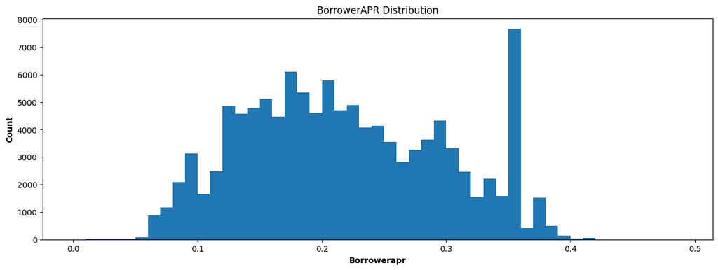

```python
hist_plot(df, 'BorrowerAPR', bin = np.arange(df.BorrowerRate.min(), df.BorrowerRate.max(), 0.01))
```

## let's see Loans Creation Date?

```python
df['LoanOriginationDate'] = pd.to_datetime(df['LoanOriginationDate'])
creat_date = df['LoanOriginationDate'].groupby(df.LoanOriginationDate.dt.to_period("Y")).agg('count')
```

```python
creat_date
```

```
LoanOriginationDate
2005       22
2006     5906
2007    11460
2008    11552
2009     2047
2010     5652
2011    11228
2012    19553
2013    34345
2014    12172
Freq: A-DEC, Name: LoanOriginationDate, dtype: int64
```

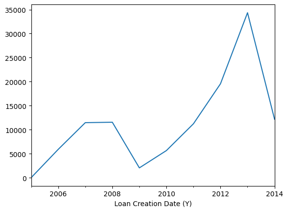

```python
creat_date.plot()
# creat_date.plot(bin= creat_bins)
# plt.xticks(rotation = 90);
plt.xlabel('Loan Creation Date (Y)')
```

## Let's look at how the number of listing are in each state

```python
state_count = df.BorrowerState.value_counts()
state_count
```

```
BorrowerState
CA    14717
TX     6842
NY     6729
FL     6720
IL     5921
GA     5008
OH     4197
MI     3593
VA     3278
NJ     3097
NC     3084
WA     3048
PA     2972
MD     2821
MO     2615
MN     2318
MA     2242
CO     2210
IN     2078
AZ     1901
WI     1842
OR     1817
TN     1737
AL     1679
CT     1627
SC     1122
NV     1090
KS     1062
KY      983
OK      971
LA      954
UT      877
AR      855
MS      787
NE      674
ID      599
NH      551
NM      472
RI      435
HI      409
WV      391
DC      382
MT      330
DE      300
VT      207
AK      200
SD      189
IA      186
WY      150
ME      101
ND       52
Name: count, dtype: int64
```

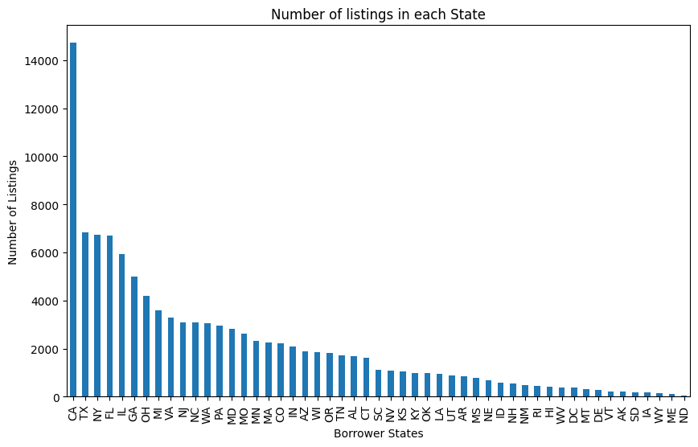

```python
colors = sb.color_palette()[0]
plt.figure(figsize=(10,6))
state_count.plot(kind='bar', color = colors)
plt.title('Number of listings in each State')
plt.xlabel('Borrower States')
plt.ylabel('Number of Listings');
```

According to the visualizations, the states with the highest listing counts are CA, TX, NY, FL, and IL, aligning with the rankings of the most populous states in the United States. Conversely, the states with the fewest listings are WY, ME, and ND. In essence, the distribution of Prosper listings appears to mirror the population distribution across the United States. see [https://en.wikipedia.org/wiki/List_of_U.S._states_and_territories_by_population]

```python
# get the BorrowerARP count
df.BorrowerAPR.value_counts().head()
```

```
BorrowerAPR
0.35797    3672
0.35643    1644
0.37453    1260
0.30532     902
0.29510     747
Name: count, dtype: int64
```

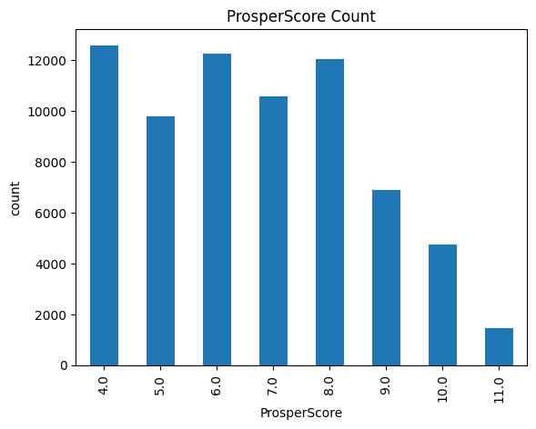

```python
order_ProsperScore = [4.0, 5.0, 6.0, 7.0, 8.0, 9.0, 10.0, 11.0]
df.ProsperScore.value_counts().loc[order_ProsperScore].plot(kind= 'bar')

plt.title('ProsperScore Count')
plt.ylabel('count')
plt.xlabel('ProsperScore')
```

## Now, let's examine the income range along with the corresponding counts.

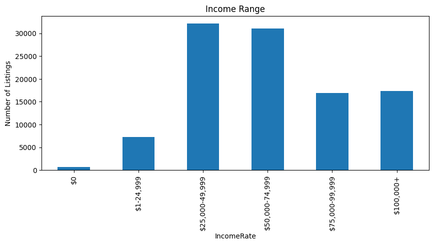

```python
# Bar graph for each income range
plt.figure(figsize=(10, 4))
order_income_range = ["$0", "$1-24,999", "$25,000-49,999", "$50,000-74,999", "$75,000-99,999", "$100,000+"]
# df.IncomeRange.value_counts().plot(kind = 'bar')
df.IncomeRange.value_counts().loc[order_income_range].plot(kind = 'bar')
plt.title('Income Range')
plt.xlabel('IncomeRate')
plt.ylabel('Number of Listings');
```

### Invesigating the Terms of loan

- Term: The length of the loan expressed in months.

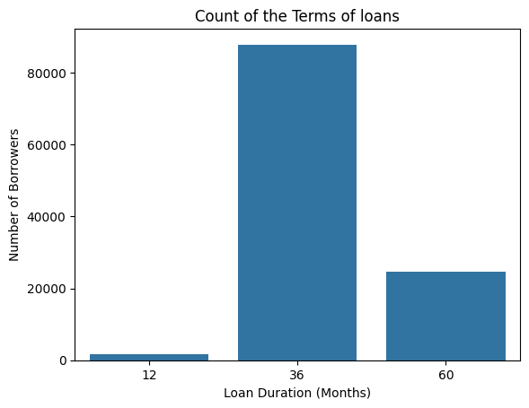

```python
#Plotting seaborn countplot with the countplot function
term_order = df['Term'].value_counts().index
# sb.countplot(data=df, x='Term', color=colors, order=term_order)
sb.countplot(data=df, x='Term', color=colors, order=[12, 36, 60])

plt.title('Count of the Terms of loans')
plt.xlabel('Loan Duration (Months)')
plt.ylabel('Number of Borrowers')
```

The most commonly chosen loan term is 36 months (considered medium-term), followed by 60 months (considered long-term), and 12 months (considered short-term).

## Bivariate Exploration

### What are the primary factors that play a role in determining the loan's interest rate?

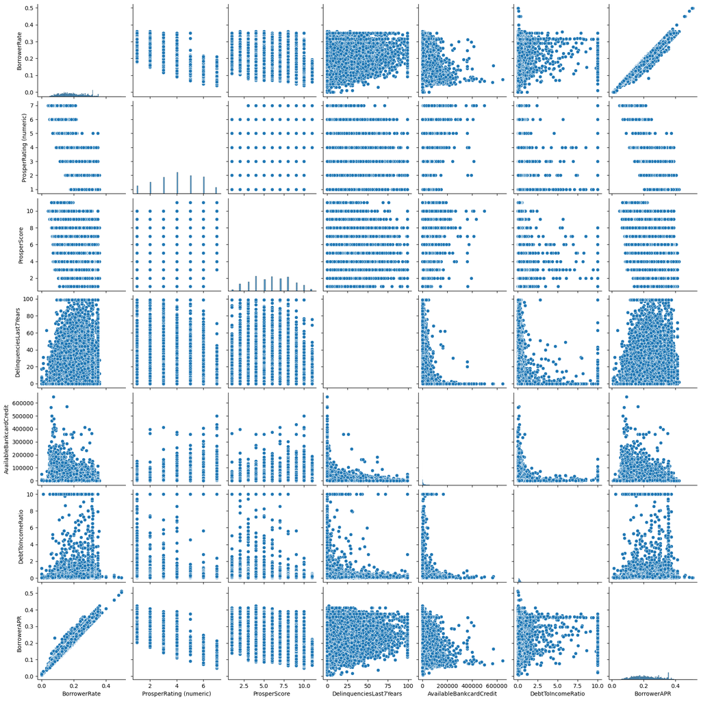

```python
sb.pairplot(df[['BorrowerRate', 'ProsperRating (numeric)', 'ProsperScore', 'DelinquenciesLast7Years','AvailableBankcardCredit',
                'DebtToIncomeRatio','BorrowerAPR']]);
```

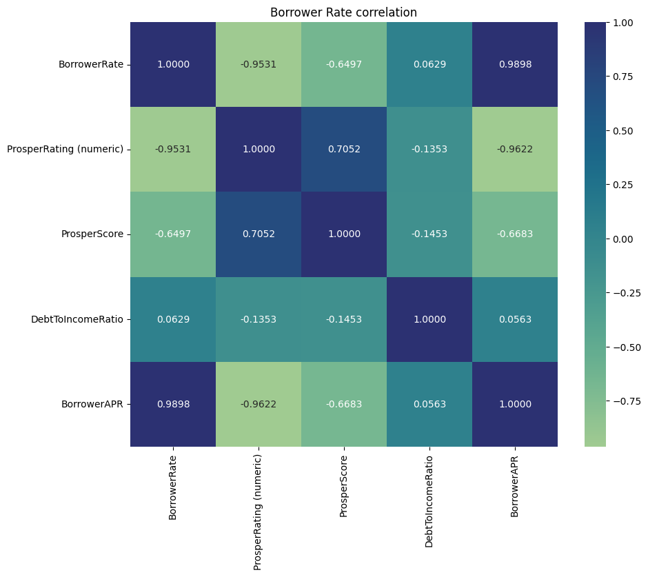

```python
corr_df = df[['BorrowerRate', 'ProsperRating (numeric)', 'ProsperScore', 'DebtToIncomeRatio','BorrowerAPR']]

plt.figure(figsize= (10,8))
sb.heatmap(corr_df.corr(), annot = True, fmt= '.4f', center= 0,
           cmap = 'crest')

plt.title('Borrower Rate correlation')
```

The ProsperRating (numeric) displays a robust correlation with BorrowerRate and ProsperScore. Notably, the DebtToIncomeRatio does not exhibit any notable correlation.

### Let's gain a deeper insight into the connection between "BorrowerAPR" and "ProsperScore.

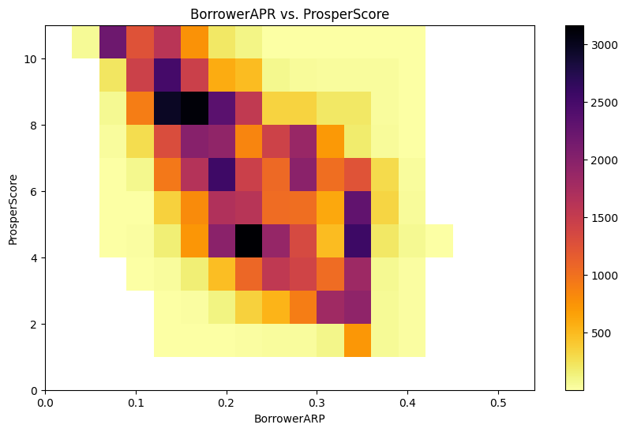

```python
plt.figure(figsize=(10, 6))

x_arp = np.arange(0, df['BorrowerAPR'].max() + 0.05, 0.03)
y_pScore = np.arange(0, df['ProsperScore'].max() + 1, 1)

plt.hist2d(data= df, x = 'BorrowerAPR', y = 'ProsperScore',
           bins= [x_arp, y_pScore], cmin= 0.5, cmap = 'inferno_r')

plt.title('BorrowerAPR vs. ProsperScore')
plt.xlabel('BorrowerARP')
plt.ylabel('ProsperScore')
plt.colorbar()
```

This is logical because individuals with higher ratings are generally considered more dependable, and as a result, they are offered lower BorrowerAPR rates.

### Let's explore BorrowerAPR, ProsperRating, and ProsperScore in greater detail.

```python
# df['IncomeRange_HvsL'] = df['IncomeRange'].apply(lambda x: x == "$25,000-49,999" or "$100,000+" )
#df['IncomeRange_HvsL'] = np.where((df['IncomeRange'] == '$25,000-49,999') | (df['IncomeRange'] == '$100,000+'), 'Low Income', 'High Income')
```

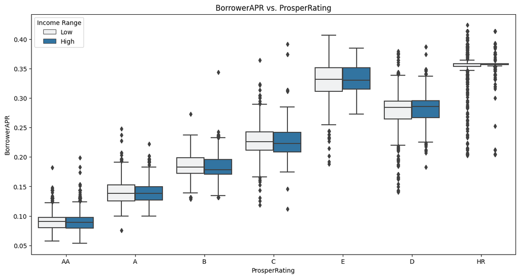

```python
plt.figure(figsize=(14,7))
sb.boxplot(data = df, x = 'ProsperRating (Alpha)', y = 'BorrowerAPR', color= colors,
           order = ['AA', 'A', 'B', 'C', 'E', 'D', 'HR'],
           hue='IncomeRange_HvsL')
plt.legend(title = 'Income Range')

plt.title('BorrowerAPR vs. ProsperRating')
plt.xlabel('ProsperRating')
plt.ylabel('BorrowerAPR');
```

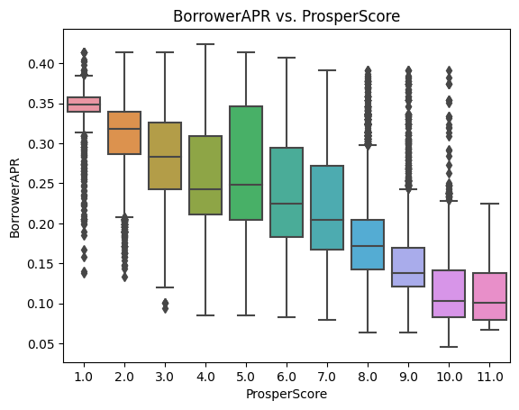

```python
sb.boxplot(data = df, x = 'ProsperScore', y = 'BorrowerAPR')
plt.title('BorrowerAPR vs. ProsperScore')
plt.xlabel('ProsperScore')
plt.ylabel('BorrowerAPR');
```

### Talk about some of the relationships you observed in this part of the investigation. How did the feature(s) of interest vary with other features in the dataset?

The ProsperRating (numeric) displays a robust correlation with BorrowerRate and ProsperScore. Notably, the DebtToIncomeRatio does not exhibit any notable correlation.

### Did you observe any interesting relationships between the other features (not the main feature(s) of interest)?

The correlation between BorrowerAPR and BorrowerRate is 0.99, which indicates that they are strongly positive correlatively. Higher BorrowerAPR rate is strongly related to higher BorrowerRate rate

## Multivariate Exploration

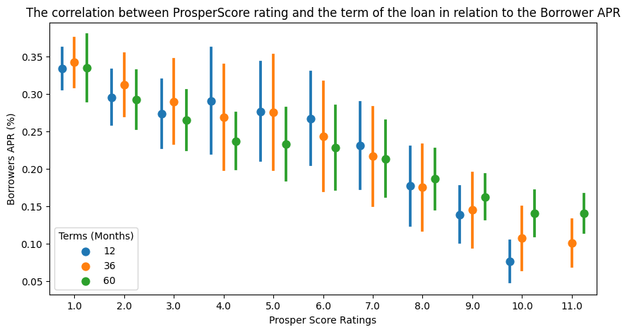

```python
plt.figure(figsize=(10,5))
sb.pointplot(data=df, x='ProsperScore', y='BorrowerAPR', hue='Term', linestyles="",
             palette='tab10', dodge=0.5, errorbar='sd');
plt.title("The correlation between ProsperScore rating and the term of the loan in relation to the Borrower APR");
plt.xlabel('Prosper Score Ratings')
plt.ylabel('Borrowers APR (%)')
plt.legend(loc = 3, title='Terms (Months)');
```

### Does the term have a significance effect on the loan and APR

- Term: The length of the loan expressed in months.

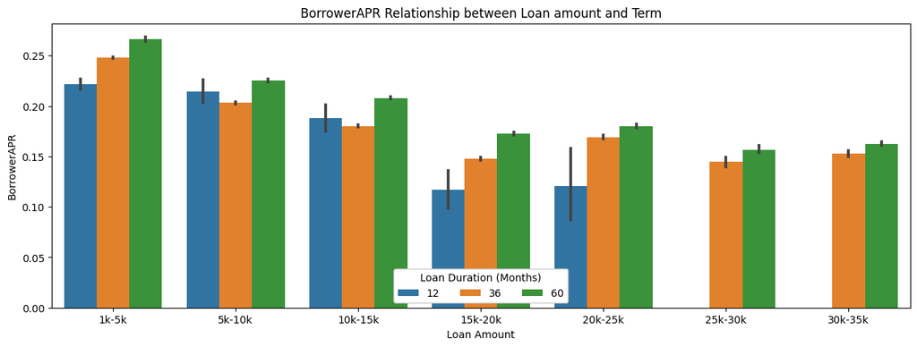

```python
# creating a bar plot for the distribution
plt.figure(figsize = [15, 5])
yx=sb.barplot(data=df,x='LoanA_range',y='BorrowerAPR',hue='Term');
yx.legend(loc = 8, ncol = 3, framealpha = 1, title = 'Loan Duration (Months)');
plt.title("BorrowerAPR Relationship between Loan amount and Term");
plt.xlabel('Loan Amount')
plt.ylabel('BorrowerAPR');
```

The trend indicates that loans with a longer term (5 years) tend to have higher borrower APRs. This implies that as individuals collect loans over an extended period, their APRs increase. This aligns with the notion that longer-term loans involve greater risk, which could explain the higher APRs.

## What is relationship of ProsperScore Rating and Loan Amount on BorrowerAPR

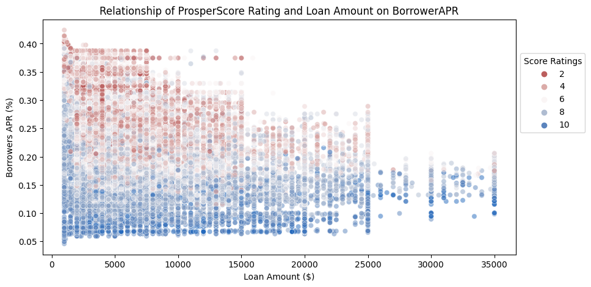

```python
plt.figure(figsize=(10,5))
sb.scatterplot(data=df, x='LoanOriginalAmount', y='BorrowerAPR', hue='ProsperScore',
             palette='vlag_r', alpha=0.5);
plt.title('Relationship of ProsperScore Rating and Loan Amount on BorrowerAPR');
plt.legend(loc = 3, bbox_to_anchor = (1.0, 0.5), title='Score Ratings');
plt.xlabel('Loan Amount ($)')
plt.ylabel('Borrowers APR (%)')
plt.show()
```

Borrowers with higher score ratings tend to enjoy more favorable BorrowerAPRs, regardless of the loan amount they take. Conversely, borrowers with lower score ratings tend to face higher BorrowerAPRs, regardless of the loan amount they borrow.

### Talk about some of the relationships you observed in this part of the investigation. Were there features that strengthened each other in terms of looking at your feature(s) of interest?

I expanded my analysis by conducting a multivariate investigation into Borrowers' APR, specifically examining how Prosper score ratings influence the relationship between Borrowers' APR and the loan amount. The multivariate exploration confirms the existence of a negative relationship between BorrowerAPR and the original loan amount. Generally, borrowers with lower score ratings typically have access to smaller loan amounts, while borrowers with higher ratings tend to access larger loan amounts.

### Were there any interesting or surprising interactions between features?

As indicated by the point plots, borrowers with lower scores tend to secure more favorable rates when seeking loans for 60 months compared to 12 and 36 months. Conversely, borrowers with higher scores often encounter higher rates when applying for loans with a 60-month term in contrast to 12 and 36 months.